# Teori Peluang

Pekan 1 – Kontrak & Pengantar Kuliah

Indira Puteri Kinasih

indiraputeri@uinmataram.ac.id

Universitas Islam Negeri Mataram

## Admin

- Dosen

$\texttt{Indira\ P.\ Kinasih}$  
$\texttt{Assistant\ Professor\ in\ Statistics}$  
$\texttt{indiraputeri.github.io}$  
$\texttt{indiraputeri@uinmataram.ac.id}$

- Perkuliahan: Setiap **Jumat**, **R.6**, Komplek FTK, Gedung B, Lt.3
  - 07.30am - 09.45am (**kls IIC**)
  - 09.45am - 12.00am (**kls IID**)
- Perhatikan material dan jadual, serta updatenya

## Deskripsi Mata Kuliah

- Mata kuliah ini dirancang untuk memperdalam pemahaman mahasiswa mengenai **ketidakpastian dan proses acak** yang mendasari analisis data dan pemodelan statistik.
- Fokus utama mata kuliah ini adalah pada pengembangan **cara berpikir probabilistik**, yaitu kemampuan untuk memodelkan situasi nyata ke dalam kerangka matematis yang terstruktur.
- Penekanan diberikan pada **pemahaman makna di balik rumus**, bukan sekadar pada perhitungan mekanis.

## *Learning Outcomes*

capaian yang diharapkan adalah mahasiswa mampu:

- Menjelaskan konsep dasar peluang meliputi percobaan acak, ruang sampel, kejadian, serta hukum-hukum dasar peluang secara sistematis.
- Menganalisis peluang kejadian menggunakan aturan penjumlahan, perkalian, dan peluang bersyarat dalam permasalahan sederhana.
- Menjelaskan dan menggunakan variabel acak diskret dan kontinu beserta karakteristiknya.

## *Learning Outcomes* (cont’d)

- Menghitung ukuran-ukuran penting variabel acak seperti nilai harapan dan varians.
- Mengidentifikasi dan menggunakan distribusi peluang penting dalam konteks sederhana.
- Membangun dan menafsirkan model probabilistik sederhana untuk merepresentasikan fenomena acak.

## Buku teks

- Casella, G., & Berger, R.L. (2002). *Statistical inference (2nd ed)*. Duxbury.
- Ross, S. M. (2019). *A first course in probability*. Pearson Boston

## Pengetahuan prasyarat

**Note**

Mahasiswa **tidak dituntut sudah mahir**, tetapi **pernah terpapar** materi berikut. Beberapa bagian akan **direview singkat** di awal perkuliahan.

**Matematika sekolah (SMA)**

- Aritmatika
- Pecahan & Percentages
- Aljabar & fungsi
- Integral & turunan (diferensiasi)

**Himpunan**

- Himpunan dan elemen himpunan
- Notasi terkait himpunan ($\in$, $\subset$, $\cup$, $\cap$)
- logika matematika

*Counting* & Penalaran

- Menghitung kemungkinan hasil suatu percobaan
- Permutasi dan kombinasi dasar
- Berpikir sistematis dan logis

## Cakupan materi

**Analisis kombinatorial**

- The basic principle of counting;
- Konsep permutasi, kombinasi;
- koefisien multinomial

**Aksioma peluang**

- Ruang sampel dan kejadian;
- Aksioma peluang, proposisi sederhana;
- Ruang sampel dengan hasil yang sama kemungkinannya;
- Peluang sebagai fungsi kontinu & ukuran tingkat keyakinan

**Peluang bersyarat & independence**

- Formula Bayes
- Kejadian saling bebas

**Distribusi peluang**

- Variabel acak(v.a), v.a diskret;
- Ekspektasi, variansi
- distribusi bernoulli, binomial, dan Poisson
- v.a kontinu
- distribusi uniform, normal, & eksponensial

## Asesmen/Penilaian

Formatif

- Quiz
- *take home mock* UTS/UAS

Sumatif

- **[25%]** UTS
- **[30%]** UAS
- **[30%]** 5 $\times$ tugas terstruktur
- **[15%]** **catatan rutin mahasiswa**

note: Catatan mahasiswa akan diobservasi 4-5 $\times$ setiap akhir topik utama selesai diberikan

## Tips belajar

1. Baca slide/buku teks/material terkait MK sebelum kuliah;
2. Ikuti perkuliahan dengan aktif;
3. Tulis ulang catatan setelah kelas;
4. Kerjakan latihan dan tugas;
5. Jika tidak paham, **TANYA** :)
6. Aktif berdiskusi dan berlatih

## Tentang mencatat

- **Catat dulu, paham belakangan**. Tak mengapa jika belum paham sepenuhnya saat dosen menjelaskan, yang penting materi tertangkap dengan baik;
- **Tulis ulang setelah kelas**. Pakai bahasamu sendiri. Ini cara paling ampuh supaya “*klik*”.
- Isi catatan sebaiknya:
  - Definisi & rumus penting; contoh soal $+$ cara mikirnya
  - Gambar, grafik, atau diagram; catatan “kenapa bisa begini?”
- **Ulangi** $=$ belajar; nikmati proses ‘mengulang’ itu
- Sedikit tapi rutin; catatan ringkas lebih efektif daripada **SKS (Sistem Kebut Semalam)** :D

## Grafik ingatan manusia

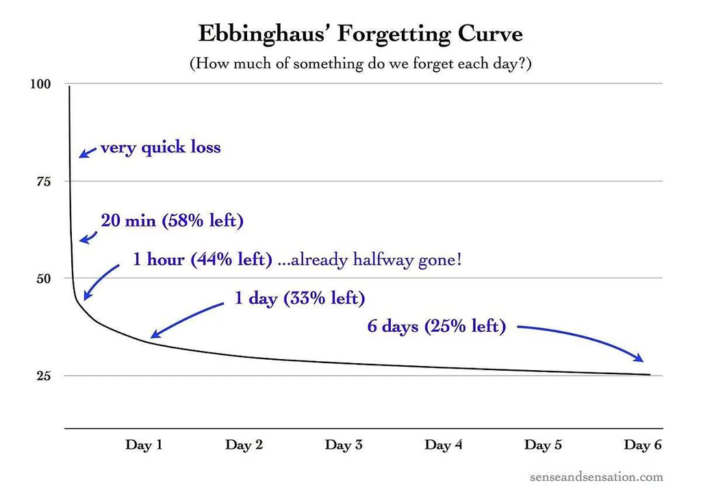

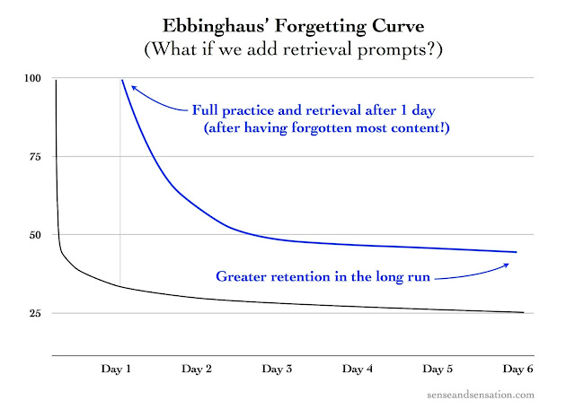

*“Apa yang dapat kalian simpulkan dari dua grafik tersebut?”*

Credit: [`Retrieval: Getting and Forgetting`](http://www.senseandsensation.com/2013/03/retrieval-getting-and-forgetting-part-8.html)

[figure not shown]